# HPLC: compute linear model to quantify compounds in standard solution (STD1+STD2).

Author

Fermlab

# Introduction

This notebook quantifies the peak areas of compounds using a dilution series of standards (see Table below). The peak areas of the compounds at different concentrations are used to compute a linear model correlating peak area and compound concentration (mM). The output is a file containing parameters of the linear model (slope, intercept) that can be applied to calculate compound concentrations in the experimental samples.

# File IO

Files used by this script.

```r
# input: sample information file
info.file = "/home/tolonen/Github/actolonen/Public/Analysis_Lab/Metabolites/HPLC/Data/information_HPLC.xlsx";

standards = read_excel(info.file, sheet = "Standards", col_names = TRUE, skip = 2);
samples = read_excel(info.file, sheet = "Samples", col_names = TRUE, skip = 2);

# input: directory of .lcd files
lcd.input.dir = "/home/tolonen/Github/actolonen/Public/Analysis_Lab/Metabolites/HPLC/Data/LCD_LabSolutions";

# output: directory of .txt files
txt.output.dir = "/home/tolonen/Github/actolonen/Public/Analysis_Lab/Metabolites/HPLC/Data/ChromConverter";

if (!dir.exists(txt.output.dir))
{
  dir.create(txt.output.dir);
}

# output: file of linear model
table.out = "/home/tolonen/Github/actolonen/Public/Analysis_Lab/Metabolites/HPLC/Data/standards_regressions_STD1.tsv";
```

Metabolite concentrations in standards samples.

```r
# Define the standards that will be used to quantify compounds.

# focus on STD1 standards.
my.standards = standards %>%
  filter(grepl("STD12_", Sample)) %>%
  filter(grepl("_water", Sample)) %>%
  mutate(Concentration_mM = round(Concentration_mM, 2)) %>%
  select(Sample, Compound, Concentration_mM);

table.standards = kable(my.standards, caption = "Table 1: Metabolite concentrations in STD1+STD2 standards");
table.standards
```

Table 1: Metabolite concentrations in STD1+STD2 standards

| Sample | Compound | Concentration_mM |
| --- | --- | --- |
| STD12_100_water | Formate | 50.00 |
| STD12_100_water | Acetate | 50.00 |
| STD12_100_water | Lactate | 50.00 |
| STD12_100_water | Ethanol | 342.50 |
| STD12_100_water | Glucose | 27.77 |
| STD12_100_water | Butyrate | 50.00 |
| STD12_100_water | Butanol | 50.00 |
| STD12_100_water | Acetone | 50.00 |
| STD12_50_water | Formate | 25.00 |
| STD12_50_water | Acetate | 25.00 |
| STD12_50_water | Lactate | 25.00 |
| STD12_50_water | Ethanol | 171.25 |
| STD12_50_water | Glucose | 13.89 |
| STD12_50_water | Butyrate | 25.00 |
| STD12_50_water | Butanol | 25.00 |
| STD12_50_water | Acetone | 25.00 |
| STD12_25_water | Formate | 12.50 |
| STD12_25_water | Acetate | 12.50 |
| STD12_25_water | Lactate | 12.50 |
| STD12_25_water | Ethanol | 85.62 |
| STD12_25_water | Glucose | 6.94 |
| STD12_25_water | Butyrate | 12.50 |
| STD12_25_water | Butanol | 12.50 |
| STD12_25_water | Acetone | 12.50 |
| STD12_12_water | Formate | 6.25 |
| STD12_12_water | Acetate | 6.25 |
| STD12_12_water | Lactate | 6.25 |
| STD12_12_water | Ethanol | 42.81 |
| STD12_12_water | Glucose | 3.47 |
| STD12_12_water | Butyrate | 6.25 |
| STD12_12_water | Butanol | 6.25 |
| STD12_12_water | Acetone | 6.25 |
| STD12_06_water | Formate | 3.12 |
| STD12_06_water | Acetate | 3.12 |
| STD12_06_water | Lactate | 3.12 |
| STD12_06_water | Ethanol | 21.41 |
| STD12_06_water | Glucose | 1.74 |
| STD12_06_water | Butyrate | 3.12 |
| STD12_06_water | Butanol | 3.12 |
| STD12_06_water | Acetone | 3.12 |

# Functions

## Calc peak areas

Calculate peak areas for a metabolite.

```r
# input = data.frame chroms.peak = Minutes, Intensity, Sample, File
# output = data.frame areas.all = Area, Concentration_mM, Sample, File

calc_areas = function(chroms.peak, my.compound)
{

# calc background-normalized intensity for each file
# calc peak area for each file
chroms.peak.norm = chroms.peak %>%
  group_by(File) %>%
    mutate(Intensity_diff = Intensity - Background) %>%
    mutate(Area = AUC(Minutes, Intensity_diff, method = 'trapezoid')) %>%
  ungroup();

# format data frame
areas.all = chroms.peak.norm %>%
  select(Area, Sample, File) %>%
  distinct();

# add standard concentrations to peak areas
standards.compound = standards %>%
  filter(Compound == my.compound);

areas.concs = left_join(areas.all, standards.compound, by="Sample");

areas.concs = areas.concs %>%
  mutate(Concentration_mM = as.numeric(Concentration_mM));

return(areas.concs);
}
```

## Calc linear model

```r
# input = areas.concs = data.frame: Concentration_mM, peak area

calc_linearModel = function(my.compound, peak.start, peak.end, my.detector, areas.concs) {

my.lm = lm(Concentration_mM ~ Area, areas.concs);
yint = my.lm$coefficients[1];
my.slope = my.lm$coefficients[2];

lm.compound = data.frame(my.compound, my.slope, yint, peak.start, peak.end, my.detector);

return(lm.compound);
}
```

# Methods

## Convert .lcd files to .txt files

Select standards .lcd files of interest

```r
# get list of all .lcd files in input dir, add sample descriptions
files.lcd.all = list.files(path = lcd.input.dir, pattern = ".lcd");
files.lcd.df = data.frame(File = files.lcd.all);
files.lcd.df = left_join(samples, files.lcd.df, by = "File");

# select standards files from standards table (Table 1)
standards.vector = unique(my.standards$Sample);
standards.list = data.frame(Sample = standards.vector);
files.standards = left_join(standards.list, files.lcd.df, by = "Sample");

# make vector of files of interest
files.lcd = as.vector(files.standards$File);
```

chromConverter to read .lcd files and .txt files.

```r
# declare empty data.frame for all samples
chromatograms.all = data.frame(
                      Minutes = double(),
                      Intensity = double(),
                      File = character(),
                      Detector = character());

for (file in files.lcd)
{
  inputfile = paste(lcd.input.dir, file, sep = "/");
  inputfile.base = str_replace(string=file, pattern=".lcd", replacement = "");

# declare a data.fram for this sample
chromatograms.sample = data.frame(
                      Minutes = double(),
                      Intensity = double(),
                      File = character(),
                      Detector = character());

  data = read_shimadzu_lcd(
     path = inputfile,
     format_out = "data.frame",
     data_format = "long",
     read_metadata = TRUE);

for (detector in data) # foreach detector (data.frame) in the data list
  {
    my.instrument = attr(detector, which = "instrument");
    my.detector = attr(detector, which = "detector");
    my.wavelength = attr(detector, which = "wavelength");
    my.detector = if_else(my.detector == "SPD-20A", true = paste(my.detector, my.wavelength, sep = " "), false = my.detector);

    detector = detector %>%
      rownames_to_column(var = "Minutes") %>%
      rename(Intensity = int) %>%
      mutate(File = file) %>%
      mutate(Detector = my.detector);
      chromatograms.sample = rbind(chromatograms.sample, detector);
  }

chromatograms.all = rbind(chromatograms.all, chromatograms.sample);

# print out chromatogram from this sample to file
chromatogram.file = paste(inputfile.base, ".txt", sep="");
chromatogram.out = paste(txt.output.dir, chromatogram.file, sep="/");
write.table(chromatograms.sample, file = chromatogram.out, row.names=FALSE, sep="\t", col.names=TRUE);
}
```

Add sample name (same as in standards table) to chromatograms data frame.

```r
chromatograms.all.desc = chromatograms.all %>%
  mutate(Minutes = as.numeric(Minutes));

# divide into replicates
chromatograms.all.desc = left_join(chromatograms.all.desc, samples, by = "File");
chromatograms.all.desc = chromatograms.all.desc %>%
  dplyr::select(Minutes, Intensity, Detector, Sample, File);

# print out first lines of chromatograms.all data frame
chromatograms.header = head(chromatograms.all.desc, 5);

table.chromatograms = kable(chromatograms.header, caption = "Table: first lines of chromatograms data frame");
table.chromatograms
```

Table: first lines of chromatograms data frame

| Minutes | Intensity | Detector | Sample | File |
| --- | --- | --- | --- | --- |
| 0.0000000 | -1.263 | SPD-20A 260nm | STD12_100_water | B2.2.lcd |
| 0.0083343 | -1.838 | SPD-20A 260nm | STD12_100_water | B2.2.lcd |
| 0.0166685 | -1.386 | SPD-20A 260nm | STD12_100_water | B2.2.lcd |
| 0.0250028 | 0.084 | SPD-20A 260nm | STD12_100_water | B2.2.lcd |
| 0.0333370 | 1.730 | SPD-20A 260nm | STD12_100_water | B2.2.lcd |

## Compound concentrations

Parse chromatograms by detector

```r
data.rid = chromatograms.all.desc %>%
  filter(Detector == "RID-10A");

data.uv210 = chromatograms.all.desc %>%
  filter(Detector == "SPD-20A 210nm");

data.uv260 = chromatograms.all.desc %>%
  filter(Detector == "SPD-20A 260nm");
```

```r
# declare output table with regression information to calculate concentrations from peak
# areas in experimental samples.

# compound_mM = Slope.reg * peak.area + Intercept.reg;

lm.out = data.frame(
    Compound = character(),
    Slope.reg = double(),
    Intercept.reg = double(),
    peak.start = double(),
    peak.end = double(),
    Detector = character()
);
```

### Acetate: RID

Calc peak areas and linear model

```r
# compound parameters
my.compound = "Acetate";
peak.start = 17.7;
peak.end = 18.9;
my.detector = "RID-10A";
my.data = data.rid;

# get background (mode) for each file
# get chromatograms for peak of interest
chroms.peak = my.data %>%
  group_by(File) %>%
    mutate(Background = min(DescTools::Mode(round(Intensity, 1)))) %>%
    filter(Minutes > peak.start & Minutes < peak.end) %>%
  ungroup();

# calculate area for peak of interest
# areas.concs = data.frame areas.all = Area, Concentration_mM, Sample, File
areas.concs = calc_areas(chroms.peak, my.compound);

# calc the linear model
lm.compound = calc_linearModel(my.compound, peak.start, peak.end, my.detector, areas.concs);
lm.out = rbind(lm.out, lm.compound);
```

Plot peaks

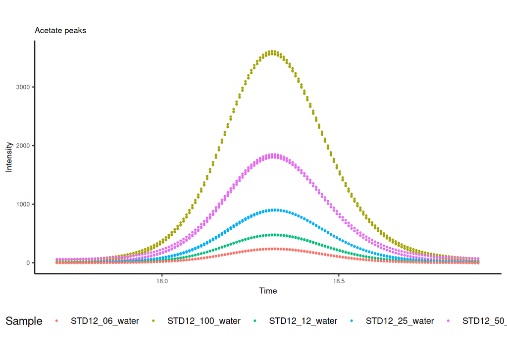

Peak areas of acetate in each of the standards samples.

```r
# plot peaks
 plot.peaks = ggplot(chroms.peak, aes(x=Minutes, y=Intensity, group=Sample, color=Sample)) +
  ggtitle(paste(my.compound, " peaks", sep=""))+
  geom_point(size=0.5) +
  xlab("Time") +
  ylab("Intensity") +
  coord_cartesian(xlim=c(peak.start, peak.end), ylim=c(min(chroms.peak$Intensity), max(chroms.peak$Intensity)))+
  theme_classic()+
  mytheme;

plot.peaks
```

Plot linear model

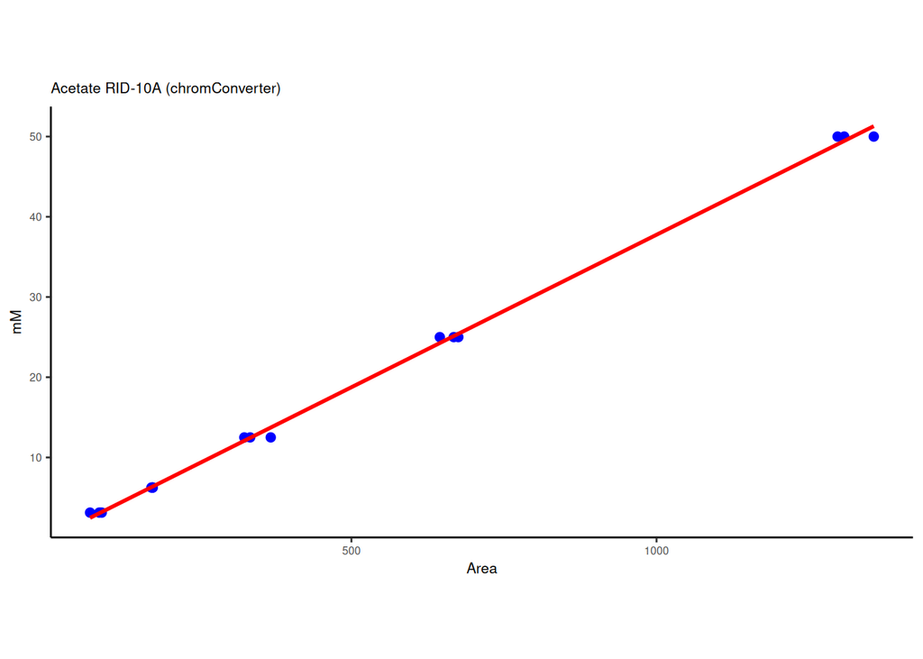

Linear regressions of peak area vs acetate concentration for all standards.

```r
plot.lm = ggplot(areas.concs, aes(x=Area, y=Concentration_mM))+
  ggtitle(paste(my.compound, my.detector, "(chromConverter)", sep = " "))+
  geom_point(size=2, color = 'blue') +
  geom_smooth(method=lm, se=FALSE, color='red', width=0.1, formula = y ~ x)+
  xlab("Area") +
  ylab("mM") +
  theme_classic() +
  mytheme;

plot.lm
```

### Acetate: UV 210

Calc peak areas

```r
# compound parameters
my.compound = "Acetate";
peak.start = 17.7;
peak.end = 18.6;
my.detector = "SPD-20A 210nm";
my.data = data.uv210;

# get background (mode) for each file
# get chromatograms for peak of interest
chroms.peak = my.data %>%
  group_by(File) %>%
    mutate(Background = min(DescTools::Mode(round(Intensity, 1)))) %>%
    filter(Minutes > peak.start & Minutes < peak.end) %>%
  ungroup();

# calculate area for peak of interest
# areas.concs = data.frame areas.all = Area, Concentration_mM, Sample, File
areas.concs = calc_areas(chroms.peak, my.compound);

# calc the linear model
lm.compound = calc_linearModel(my.compound, peak.start, peak.end, my.detector, areas.concs);
lm.out = rbind(lm.out, lm.compound);
```

Plot peaks

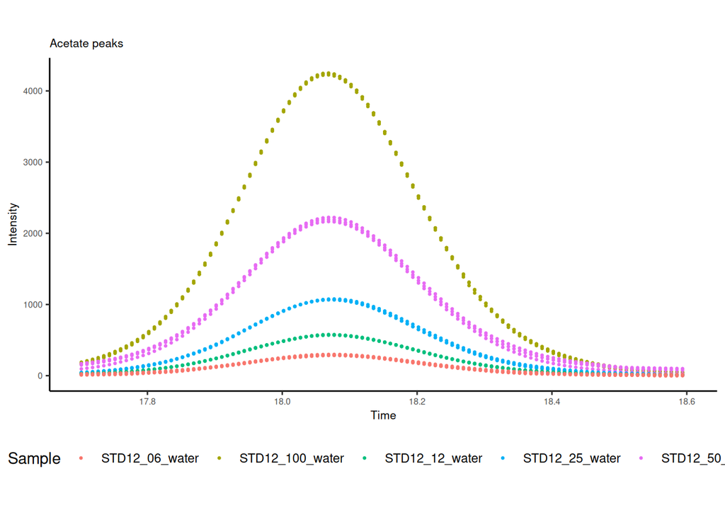

Peak areas of acetate in each of the standards samples.

```r
# plot peaks
 plot.peaks = ggplot(chroms.peak, aes(x=Minutes, y=Intensity, group=Sample, color=Sample)) +
  ggtitle(paste(my.compound, " peaks", sep=""))+
  geom_point(size=0.5) +
  xlab("Time") +
  ylab("Intensity") +
  coord_cartesian(xlim=c(peak.start, peak.end), ylim=c(min(chroms.peak$Intensity), max(chroms.peak$Intensity)))+
  theme_classic()+
  mytheme;

plot.peaks
```

Plot linear model

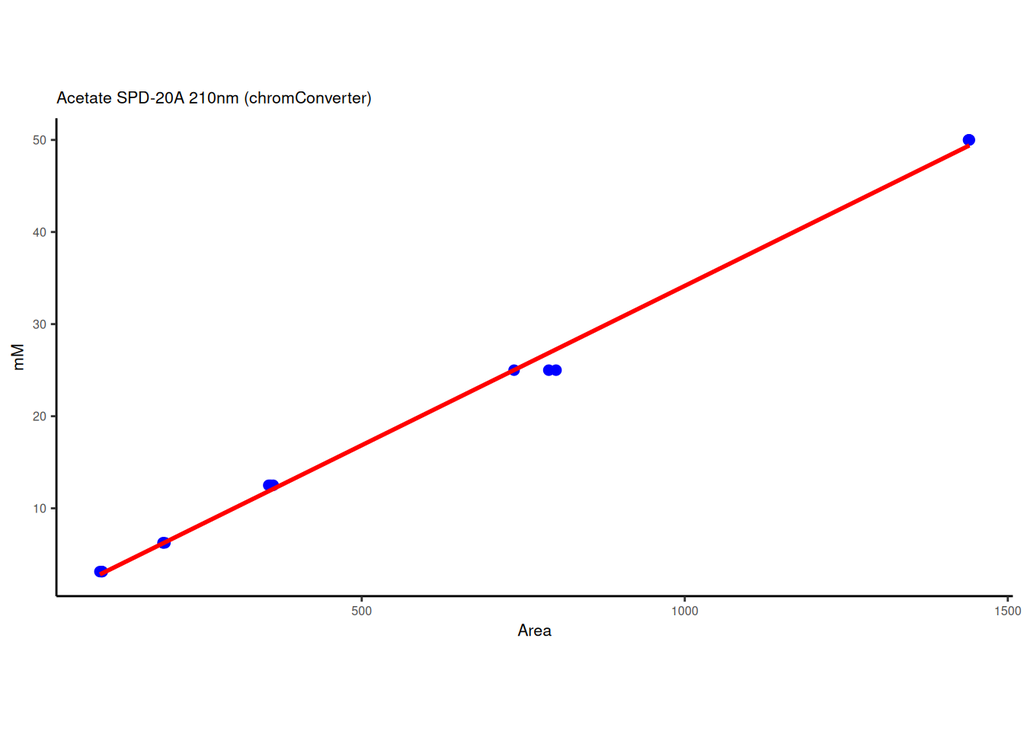

Linear regressions of peak area vs acetate concentration for all standards.

```r
plot.lm = ggplot(areas.concs, aes(x=Area, y=Concentration_mM))+
  ggtitle(paste(my.compound, my.detector, "(chromConverter)", sep = " "))+
  geom_point(size=2, color = 'blue') +
  geom_smooth(method=lm, se=FALSE, color='red', width=0.1, formula = y ~ x)+
  xlab("Area") +
  ylab("mM") +
  theme_classic() +
  mytheme;

# print regressions
 bothplots = grid.arrange(plot.lm, ncol = 1);
```

### Ethanol: RID

Calc peak areas

```r
# compound parameters
my.compound = "Ethanol";
peak.start = 26.1;
peak.end = 27.7;
my.detector = "RID-10A";
my.data = data.rid;

# get background (mode) for each file
# get chromatograms for peak of interest
chroms.peak = my.data %>%
  group_by(File) %>%
    mutate(Background = min(DescTools::Mode(round(Intensity, 1)))) %>%
    filter(Minutes > peak.start & Minutes < peak.end) %>%
  ungroup();

# calculate area for peak of interest
# areas.concs = data.frame areas.all = Area, Concentration_mM, Sample, File
areas.concs = calc_areas(chroms.peak, my.compound);

# calc the linear model
lm.compound = calc_linearModel(my.compound, peak.start, peak.end, my.detector, areas.concs);
lm.out = rbind(lm.out, lm.compound);
```

Plot peaks

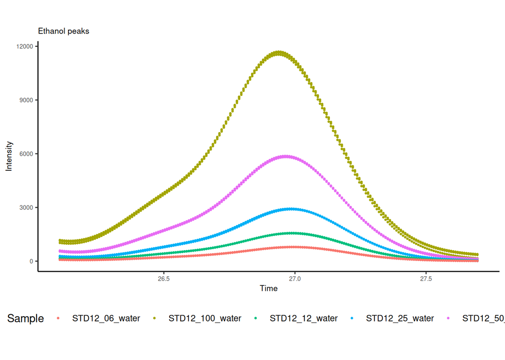

Peak areas of ethanol in each of the standards samples.

```r
# plot peaks
 plot.peaks = ggplot(chroms.peak, aes(x=Minutes, y=Intensity, group=Sample, color=Sample)) +
  ggtitle(paste(my.compound, " peaks", sep=""))+
  geom_point(size=0.5) +
  xlab("Time") +
  ylab("Intensity") +
  coord_cartesian(xlim=c(peak.start, peak.end), ylim=c(min(chroms.peak$Intensity), max(chroms.peak$Intensity)))+
  theme_classic()+
  mytheme;

plot.peaks
```

Plot linear model

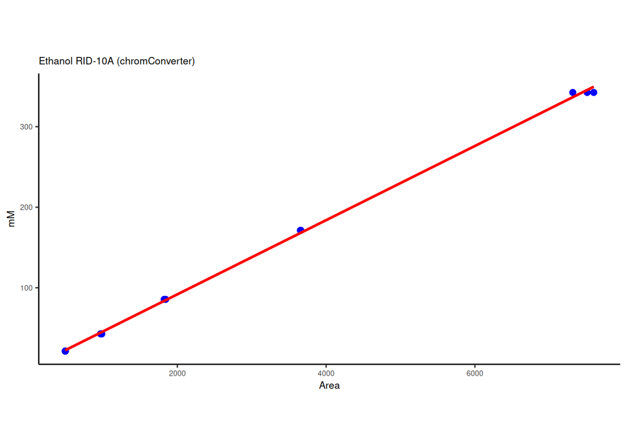

Linear regressions of peak area vs ethanol concentration for all standards.

```r
plot.lm = ggplot(areas.concs, aes(x=Area, y=Concentration_mM))+
  ggtitle(paste(my.compound, my.detector, "(chromConverter)", sep = " "))+
  geom_point(size=2, color = 'blue') +
  geom_smooth(method=lm, se=FALSE, color='red', width=0.1, formula = y ~ x)+
  xlab("Area") +
  ylab("mM") +
  theme_classic() +
  mytheme;

# print regressions
 bothplots = grid.arrange(plot.lm, ncol = 1);
```

### Lactate: RID

Calc peak areas, lm

```r
# compound parameters
my.compound = "Lactate";
peak.start = 15.1;
peak.end = 16.1;
my.detector = "RID-10A";
my.data = data.rid;

# get background (mode) for each file
# get chromatograms for peak of interest
chroms.peak = my.data %>%
  group_by(File) %>%
    mutate(Background = min(DescTools::Mode(round(Intensity, 1)))) %>%
    filter(Minutes > peak.start & Minutes < peak.end) %>%
  ungroup();

# calculate area for peak of interest
# areas.concs = data.frame areas.all = Area, Concentration_mM, Sample, File
areas.concs = calc_areas(chroms.peak, my.compound);

# calc the linear model
lm.compound = calc_linearModel(my.compound, peak.start, peak.end, my.detector, areas.concs);
lm.out = rbind(lm.out, lm.compound);
```

Plot peaks

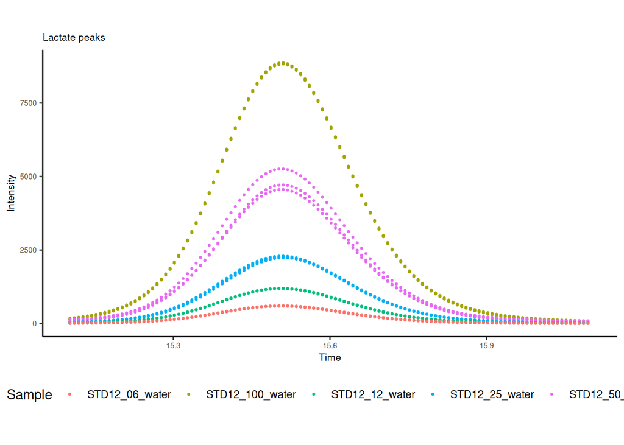

Peak areas of lactate in each of the standards samples.

```r
# plot peaks
 plot.peaks = ggplot(chroms.peak, aes(x=Minutes, y=Intensity, group=Sample, color=Sample)) +
  ggtitle(paste(my.compound, " peaks", sep=""))+
  geom_point(size=0.5) +
  xlab("Time") +
  ylab("Intensity") +
  coord_cartesian(xlim=c(peak.start, peak.end), ylim=c(min(chroms.peak$Intensity), max(chroms.peak$Intensity)))+
  theme_classic()+
  mytheme;

plot.peaks
```

Plot linear model

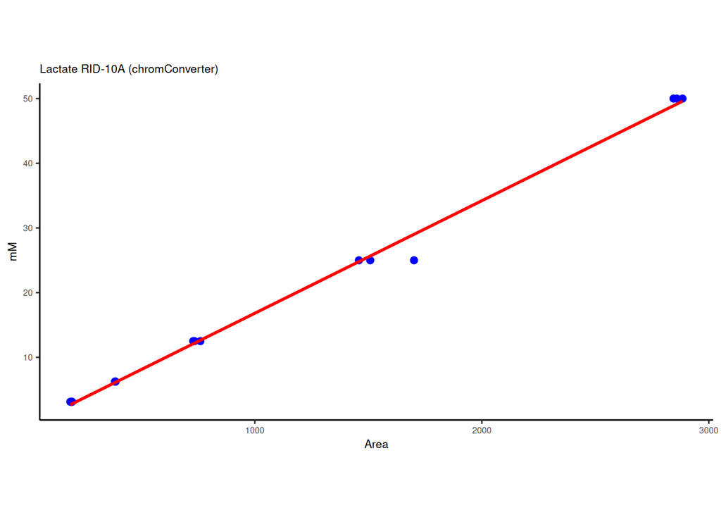

Linear regressions of peak area vs lactate concentration for all standards.

```r
plot.lm = ggplot(areas.concs, aes(x=Area, y=Concentration_mM))+
  ggtitle(paste(my.compound, my.detector, "(chromConverter)", sep = " "))+
  geom_point(size=2, color = 'blue') +
  geom_smooth(method=lm, se=FALSE, color='red', width=0.1, formula = y ~ x)+
  xlab("Area") +
  ylab("mM") +
  theme_classic() +
  mytheme;

# print regressions
 bothplots = grid.arrange(plot.lm, ncol = 1);
```

### Lactate: UV 210

Calc peak areas, linear model

```r
# compound parameters
my.compound = "Lactate";
peak.start = 14.9;
peak.end = 15.8;
my.detector = "SPD-20A 210nm";
my.data = data.uv210;

# get background (mode) for each file
# get chromatograms for peak of interest
chroms.peak = my.data %>%
  group_by(File) %>%
    mutate(Background = min(DescTools::Mode(round(Intensity, 1)))) %>%
    filter(Minutes > peak.start & Minutes < peak.end) %>%
  ungroup();

# calculate area for peak of interest
# areas.concs = data.frame areas.all = Area, Concentration_mM, Sample, File
areas.concs = calc_areas(chroms.peak, my.compound);

# calc the linear model
lm.compound = calc_linearModel(my.compound, peak.start, peak.end, my.detector, areas.concs);
lm.out = rbind(lm.out, lm.compound);
```

Plot peaks

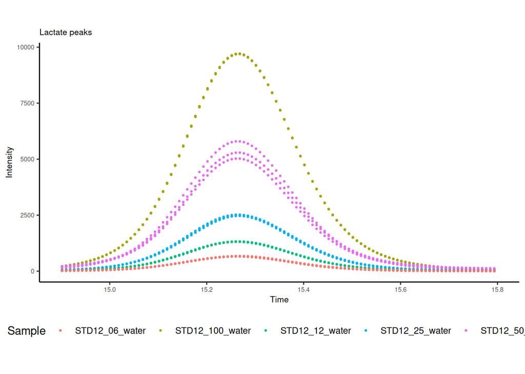

Peak areas of lactate in each of the standards samples.

```r
# plot peaks
 plot.peaks = ggplot(chroms.peak, aes(x=Minutes, y=Intensity, group=Sample, color=Sample)) +
  ggtitle(paste(my.compound, " peaks", sep=""))+
  geom_point(size=0.5) +
  xlab("Time") +
  ylab("Intensity") +
  coord_cartesian(xlim=c(peak.start, peak.end), ylim=c(min(chroms.peak$Intensity), max(chroms.peak$Intensity)))+
  theme_classic()+
  mytheme;

plot.peaks
```

Plot linear model

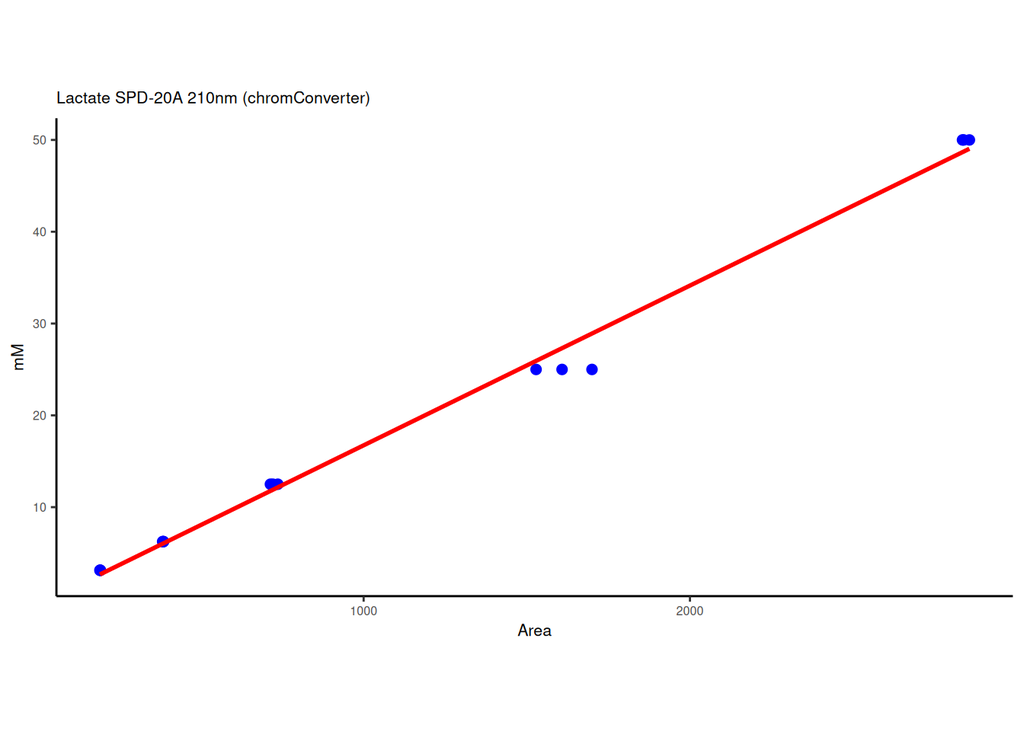

Linear regressions of peak area vs lactate concentration for all standards.

```r
plot.lm = ggplot(areas.concs, aes(x=Area, y=Concentration_mM))+
  ggtitle(paste(my.compound, my.detector, "(chromConverter)", sep = " "))+
  geom_point(size=2, color = 'blue') +
  geom_smooth(method=lm, se=FALSE, color='red', width=0.1, formula = y ~ x)+
  xlab("Area") +
  ylab("mM") +
  theme_classic() +
  mytheme;

# print regressions
 bothplots = grid.arrange(plot.lm, ncol = 1);
```

### Formate: RID

Calc peak areas, lm

```r
# compound parameters
my.compound = "Formate";
peak.start = 16.4;
peak.end = 17.4;
my.detector = "RID-10A";
my.data = data.rid;

# get background (mode) for each file
# get chromatograms for peak of interest
chroms.peak = my.data %>%
  group_by(File) %>%
    mutate(Background = min(DescTools::Mode(round(Intensity, 1)))) %>%
    filter(Minutes > peak.start & Minutes < peak.end) %>%
  ungroup();

# calculate area for peak of interest
# areas.concs = data.frame areas.all = Area, Concentration_mM, Sample, File
areas.concs = calc_areas(chroms.peak, my.compound);

# calc the linear model
lm.compound = calc_linearModel(my.compound, peak.start, peak.end, my.detector, areas.concs);
lm.out = rbind(lm.out, lm.compound);
```

Plot peaks

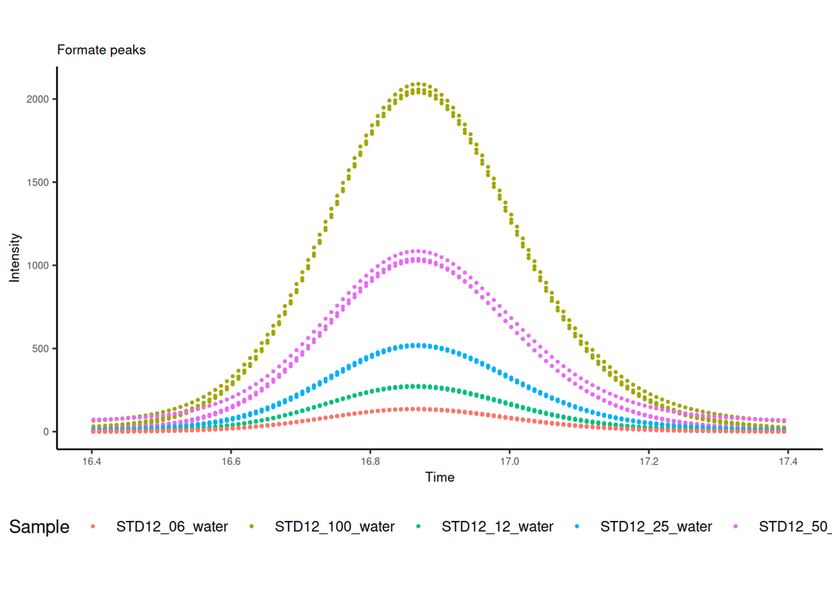

Peak areas of formate in each of the standards samples.

```r
# plot peaks
 plot.peaks = ggplot(chroms.peak, aes(x=Minutes, y=Intensity, group=Sample, color=Sample)) +
  ggtitle(paste(my.compound, " peaks", sep=""))+
  geom_point(size=0.5) +
  xlab("Time") +
  ylab("Intensity") +
  coord_cartesian(xlim=c(peak.start, peak.end), ylim=c(min(chroms.peak$Intensity), max(chroms.peak$Intensity)))+
  theme_classic()+
  mytheme;

plot.peaks
```

Plot linear model

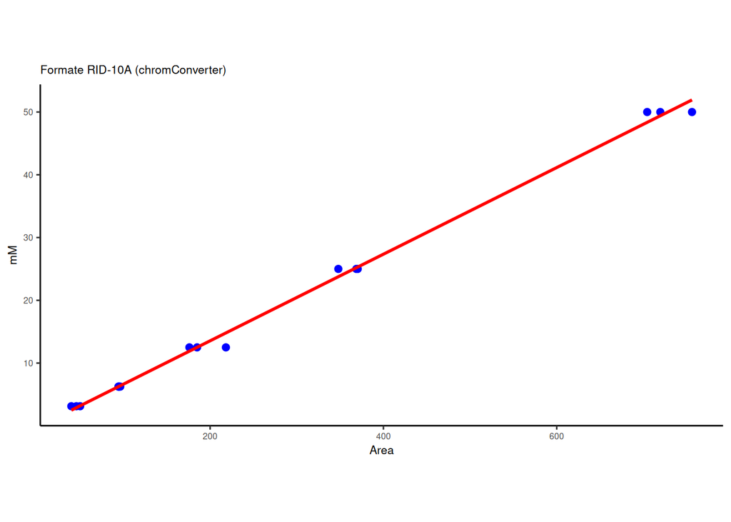

Linear regressions of peak area vs formate concentration for all standards.

```r
plot.lm = ggplot(areas.concs, aes(x=Area, y=Concentration_mM))+
  ggtitle(paste(my.compound, my.detector, "(chromConverter)", sep = " "))+
  geom_point(size=2, color = 'blue') +
  geom_smooth(method=lm, se=FALSE, color='red', width=0.1, formula = y ~ x)+
  xlab("Area") +
  ylab("mM") +
  theme_classic() +
  mytheme;

# print regressions
 bothplots = grid.arrange(plot.lm, ncol = 1);
```

### Formate: UV210

Calc peaks, lm

```r
# compound parameters
my.compound = "Formate";
peak.start = 16.2;
peak.end = 17.3;
my.detector = "SPD-20A 210nm";
my.data = data.uv210;

# get background (mode) for each file
# get chromatograms for peak of interest
chroms.peak = my.data %>%
  group_by(File) %>%
    mutate(Background = min(DescTools::Mode(round(Intensity, 1)))) %>%
    filter(Minutes > peak.start & Minutes < peak.end) %>%
  ungroup();

# calculate area for peak of interest
# areas.concs = data.frame areas.all = Area, Concentration_mM, Sample, File
areas.concs = calc_areas(chroms.peak, my.compound);

# calc the linear model
lm.compound = calc_linearModel(my.compound, peak.start, peak.end, my.detector, areas.concs);
lm.out = rbind(lm.out, lm.compound);
```

Plot peaks

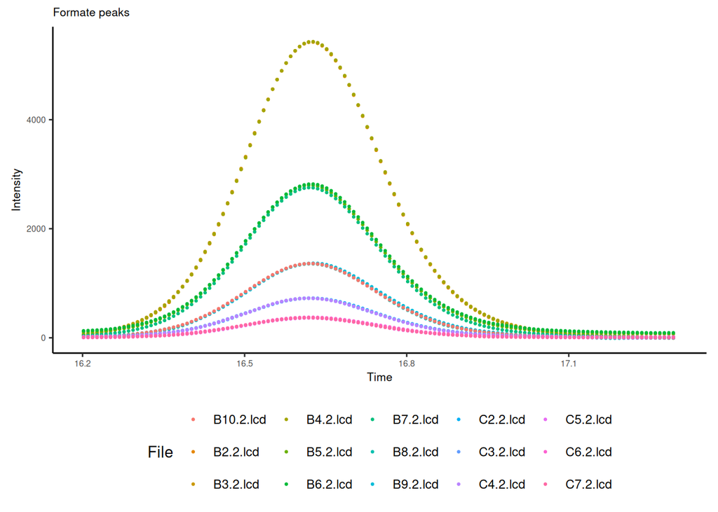

Peak areas of formate in each of the standards samples.

```r
# plot peaks
 plot.peaks = ggplot(chroms.peak, aes(x=Minutes, y=Intensity, group=File, color=File)) +
  ggtitle(paste(my.compound, " peaks", sep=""))+
  geom_point(size=0.5) +
  xlab("Time") +
  ylab("Intensity") +
  coord_cartesian(xlim=c(peak.start, peak.end), ylim=c(min(chroms.peak$Intensity), max(chroms.peak$Intensity)))+
  theme_classic()+
  mytheme;

plot.peaks
```

Plot linear model

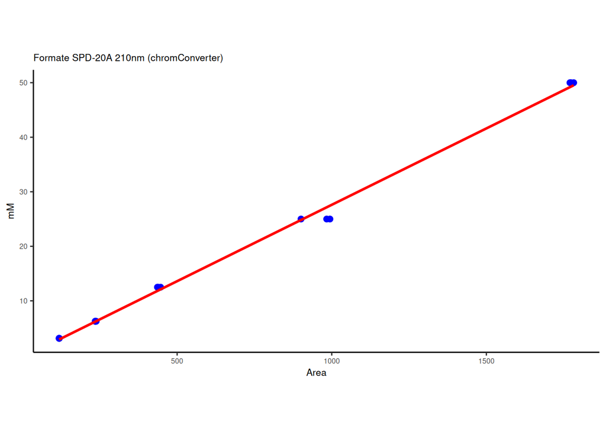

Linear regressions of peak area vs formate concentration for all standards.

```r
plot.lm = ggplot(areas.concs, aes(x=Area, y=Concentration_mM))+
  ggtitle(paste(my.compound, my.detector, "(chromConverter)", sep = " "))+
  geom_point(size=2, color = 'blue') +
  geom_smooth(method=lm, se=FALSE, color='red', width=0.1, formula = y ~ x)+
  xlab("Area") +
  ylab("mM") +
  theme_classic() +
  mytheme;

# print regressions
 bothplots = grid.arrange(plot.lm, ncol = 1);
```

### Glucose: RID

Calc peak areas

```r
# compound parameters
my.compound = "Glucose";
peak.start = 10.7;
peak.end = 11.7;
my.detector = "RID-10A";
my.data = data.rid;

# get background (mode) for each file
# get chromatograms for peak of interest
chroms.peak = my.data %>%
  group_by(File) %>%
    mutate(Background = min(DescTools::Mode(round(Intensity, 1)))) %>%
    filter(Minutes > peak.start & Minutes < peak.end) %>%
  ungroup();

# calculate area for peak of interest
# areas.concs = data.frame areas.all = Area, Concentration_mM, Sample, File
areas.concs = calc_areas(chroms.peak, my.compound);

# calc the linear model
lm.compound = calc_linearModel(my.compound, peak.start, peak.end, my.detector, areas.concs);
lm.out = rbind(lm.out, lm.compound);
```

Plot peaks

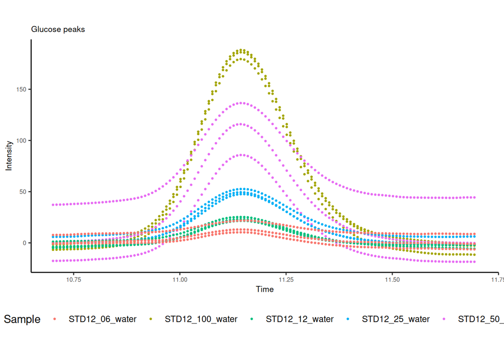

Peak areas of glucose in each of the standards samples.

```r
# plot peaks
 plot.peaks = ggplot(chroms.peak, aes(x=Minutes, y=Intensity, group=Sample, color=Sample)) +
  ggtitle(paste(my.compound, " peaks", sep=""))+
  geom_point(size=0.5) +
  xlab("Time") +
  ylab("Intensity") +
  coord_cartesian(xlim=c(peak.start, peak.end), ylim=c(min(chroms.peak$Intensity), max(chroms.peak$Intensity)))+
  theme_classic()+
  mytheme;

plot.peaks
```

Plot regressions

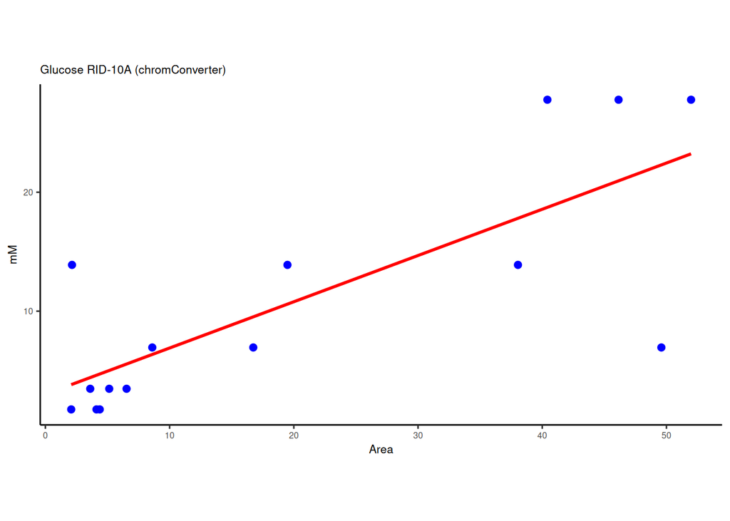

Linear regressions of peak area vs glucose concentration for all standards.

```r
plot.lm = ggplot(areas.concs, aes(x=Area, y=Concentration_mM))+
  ggtitle(paste(my.compound, my.detector, "(chromConverter)", sep = " "))+
  geom_point(size=2, color = 'blue') +
  geom_smooth(method=lm, se=FALSE, color='red', width=0.1, formula = y ~ x)+
  xlab("Area") +
  ylab("mM") +
  theme_classic() +
  mytheme;

# print regressions
 bothplots = grid.arrange(plot.lm, ncol = 1);
```

### Butyrate: UV 210 nm

Calc peak areas and linear model

```r
# compound parameters
my.compound = "Butyrate";
peak.start = 24.5;
peak.end = 26.5;
Detector = "SPD-20A 210nm";
my.data = data.uv210;

# get background (mode) for each file
# get chromatograms for peak of interest
chroms.peak = my.data %>%
  group_by(File) %>%
    mutate(Background = min(DescTools::Mode(round(Intensity, 1)))) %>%
    filter(Minutes > peak.start & Minutes < peak.end) %>%
  ungroup();

# calculate area for peak of interest
# areas.concs = data.frame areas.all = Area, Concentration_mM, Sample, File
areas.concs = calc_areas(chroms.peak, my.compound);

# calc the linear model
lm.compound = calc_linearModel(my.compound, peak.start, peak.end, my.detector, areas.concs);
lm.out = rbind(lm.out, lm.compound);
```

Plot peaks

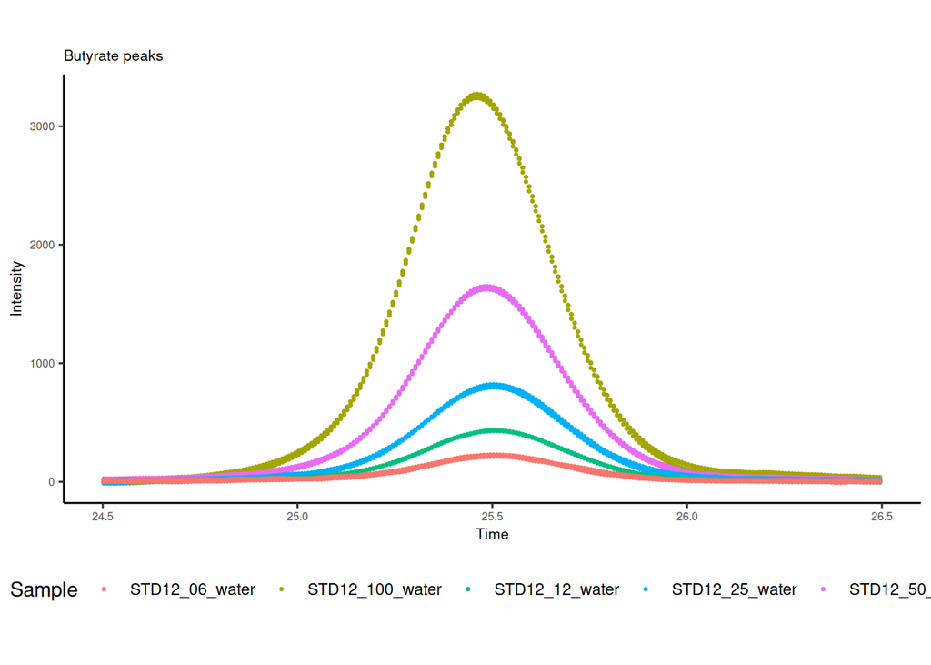

Peak areas of butyrate in each of the standards samples.

```r
# plot peaks
 plot.peaks = ggplot(chroms.peak, aes(x=Minutes, y=Intensity, group=Sample, color=Sample)) +
  ggtitle(paste(my.compound, " peaks", sep=""))+
  geom_point(size=0.5) +
  xlab("Time") +
  ylab("Intensity") +
  coord_cartesian(xlim=c(peak.start, peak.end), ylim=c(min(chroms.peak$Intensity), max(chroms.peak$Intensity)))+
  theme_classic()+
  mytheme;

plot.peaks
```

Plot linear model

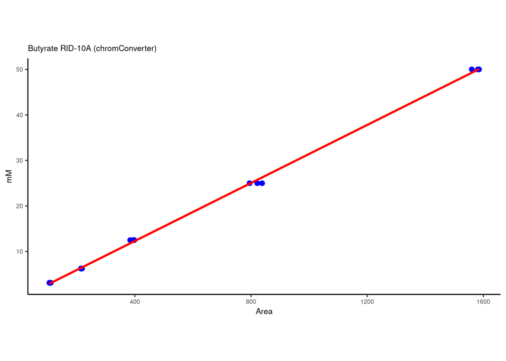

Linear regressions of peak area vs butyrate concentration for all standards.

```r
plot.lm = ggplot(areas.concs, aes(x=Area, y=Concentration_mM))+
  ggtitle(paste(my.compound, my.detector, "(chromConverter)", sep = " "))+
  geom_point(size=2, color = 'blue') +
  geom_smooth(method=lm, se=FALSE, color='red', width=0.1, formula = y ~ x)+
  xlab("Area") +
  ylab("mM") +
  theme_classic() +
  mytheme;

plot.lm
```

### Butanol: RID

Calc peak areas

```r
# compound parameters
my.compound = "Butanol";
peak.start = 43.8;
peak.end = 46;
Detector = "RID-10A";
my.data = data.rid;

# get background (mode) for each file
# get chromatograms for peak of interest
chroms.peak = my.data %>%
  group_by(File) %>%
    mutate(Background = min(DescTools::Mode(round(Intensity, 1)))) %>%
    filter(Minutes > peak.start & Minutes < peak.end) %>%
  ungroup();

# calculate area for peak of interest
# areas.concs = data.frame areas.all = Area, Concentration_mM, Sample, File
areas.concs = calc_areas(chroms.peak, my.compound);

# calc the linear model
lm.compound = calc_linearModel(my.compound, peak.start, peak.end, my.detector, areas.concs);
lm.out = rbind(lm.out, lm.compound);
```

Plot peaks

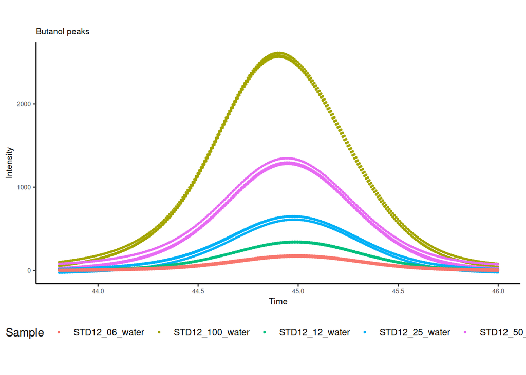

Peak areas of butanol in each of the standards samples.

```r
# plot peaks
 plot.peaks = ggplot(chroms.peak, aes(x=Minutes, y=Intensity, group=Sample, color=Sample)) +
  ggtitle(paste(my.compound, " peaks", sep=""))+
  geom_point(size=0.5) +
  xlab("Time") +
  ylab("Intensity") +
  coord_cartesian(xlim=c(peak.start, peak.end), ylim=c(min(chroms.peak$Intensity), max(chroms.peak$Intensity)))+
  theme_classic()+
  mytheme;

plot.peaks
```

Plot linear model

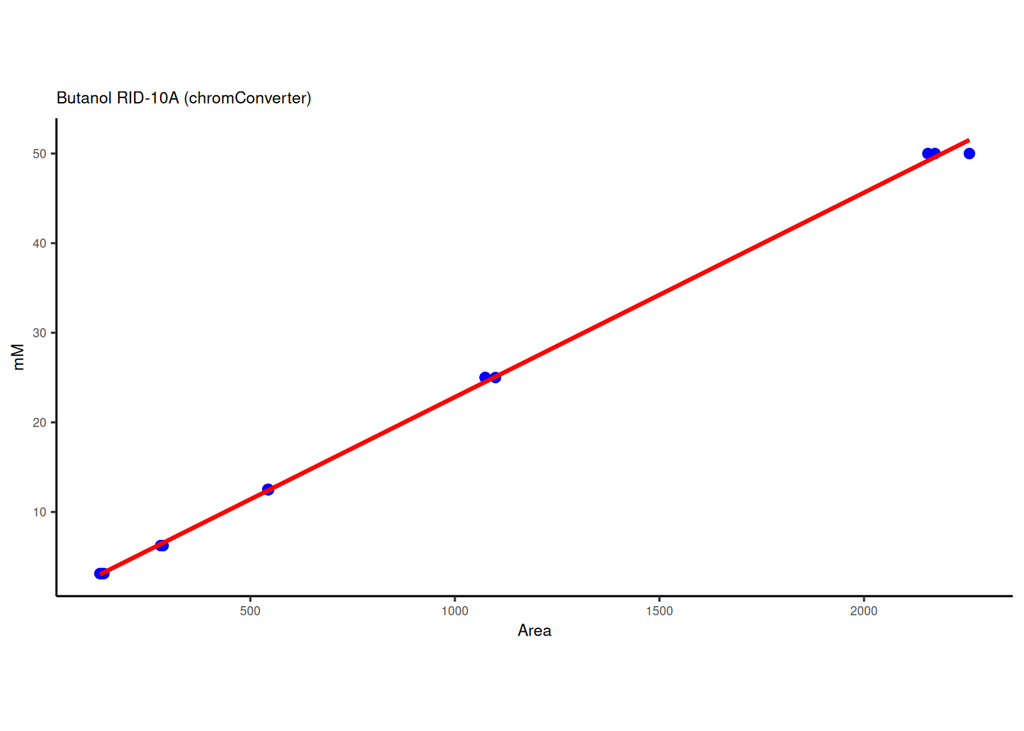

Linear regressions of peak area vs butanol concentration for all standards.

```r
plot.lm = ggplot(areas.concs, aes(x=Area, y=Concentration_mM))+
  ggtitle(paste(my.compound, my.detector, "(chromConverter)", sep = " "))+
  geom_point(size=2, color = 'blue') +
  geom_smooth(method=lm, se=FALSE, color='red', width=0.1, formula = y ~ x)+
  xlab("Area") +
  ylab("mM") +
  theme_classic() +
  mytheme;

# print regressions
 bothplots = grid.arrange(plot.lm, ncol = 1);
```

### Acetone: UV 260 nm

Calc peak areas

```r
# compound parameters
my.compound = "Acetone";
peak.start = 25.5;
peak.end = 27;
Detector = "SPD-20A 260nm";
my.data = data.uv260;

# get background (mode) for each file
# get chromatograms for peak of interest
chroms.peak = my.data %>%
  group_by(File) %>%
    mutate(Background = min(DescTools::Mode(round(Intensity, 1)))) %>%
    filter(Minutes > peak.start & Minutes < peak.end) %>%
  ungroup();

# calculate area for peak of interest
# areas.concs = data.frame areas.all = Area, Concentration_mM, Sample, File
areas.concs = calc_areas(chroms.peak, my.compound);

# calc the linear model
lm.compound = calc_linearModel(my.compound, peak.start, peak.end, my.detector, areas.concs);
lm.out = rbind(lm.out, lm.compound);
```

Plot peaks

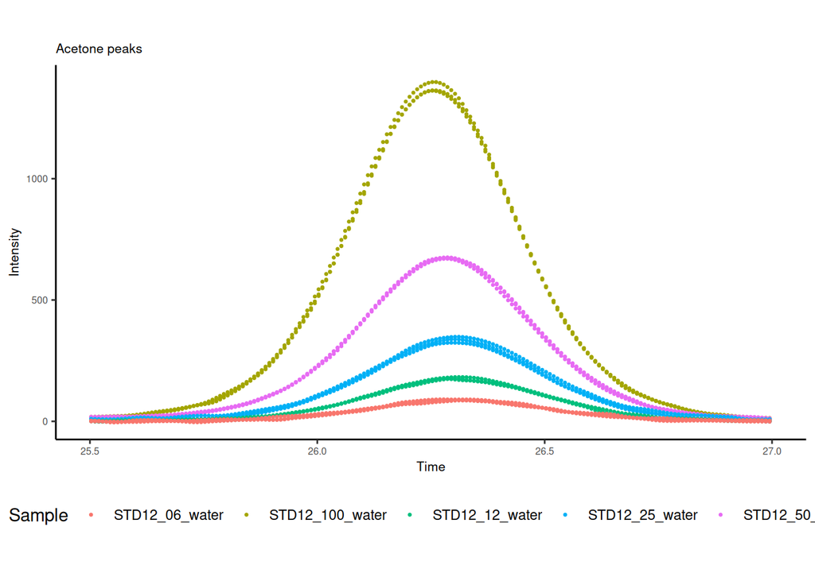

Peak areas of acetone in each of the standards samples.

```r
# plot peaks
 plot.peaks = ggplot(chroms.peak, aes(x=Minutes, y=Intensity, group=Sample, color=Sample)) +
  ggtitle(paste(my.compound, " peaks", sep=""))+
  geom_point(size=0.5) +
  xlab("Time") +
  ylab("Intensity") +
  coord_cartesian(xlim=c(peak.start, peak.end), ylim=c(min(chroms.peak$Intensity), max(chroms.peak$Intensity)))+
  theme_classic()+
  mytheme;

plot.peaks
```

Plot linear model

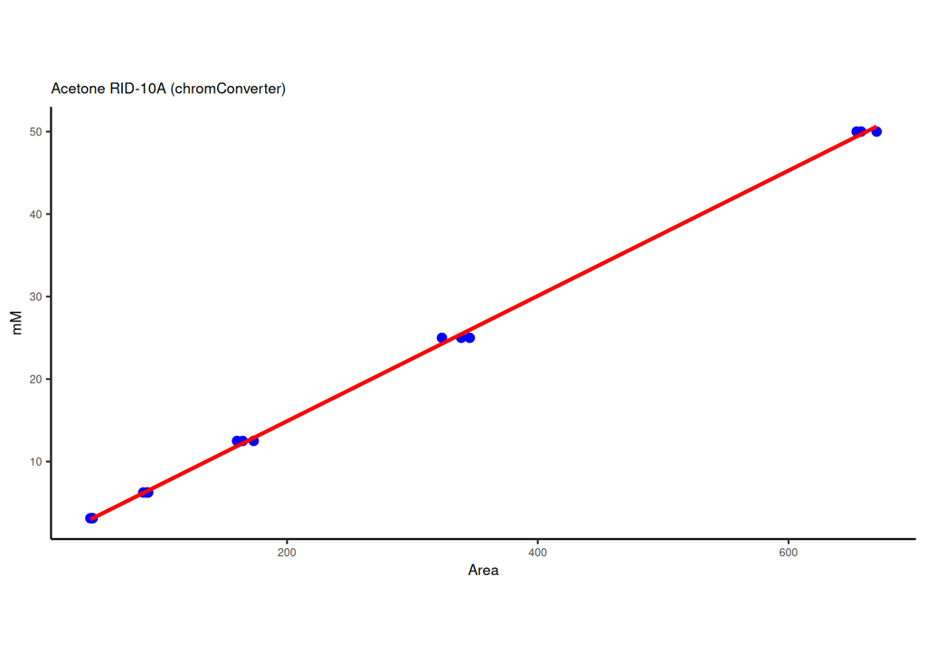

Linear regressions of peak area vs acetone concentration for all standards.

```r
plot.lm = ggplot(areas.concs, aes(x=Area, y=Concentration_mM))+
  ggtitle(paste(my.compound, my.detector, "(chromConverter)", sep = " "))+
  geom_point(size=2, color = 'blue') +
  geom_smooth(method=lm, se=FALSE, color='red', width=0.1, formula = y ~ x)+
  xlab("Area") +
  ylab("mM") +
  theme_classic() +
  mytheme;

# print regressions
 bothplots = grid.arrange(plot.lm, ncol = 1);
```

## Output regression parameters

```r
# rename cols for output
lm.out = lm.out %>%
  rename(Compound = my.compound, Slope = my.slope, Y.Intercept = yint, Peak.start = peak.start, Peak.end = peak.end);

table.regression = kable(lm.out, caption = "Table: regression parameters for each metabolite.", row.names = F);
table.regression
```

Table: regression parameters for each metabolite.

| Compound | Slope | Y.Intercept | Peak.start | Peak.end | my.detector |
| --- | --- | --- | --- | --- | --- |
| Acetate | 0.0380128 | -0.2500837 | 17.7 | 18.9 | RID-10A |
| Acetate | 0.0346170 | -0.4609136 | 17.7 | 18.6 | SPD-20A 210nm |
| Ethanol | 0.0460501 | -0.2414805 | 26.1 | 27.7 | RID-10A |
| Lactate | 0.0173976 | -0.5831854 | 15.1 | 16.1 | RID-10A |
| Lactate | 0.0174015 | -0.6649423 | 14.9 | 15.8 | SPD-20A 210nm |
| Formate | 0.0690215 | -0.2595174 | 16.4 | 17.4 | RID-10A |
| Formate | 0.0280138 | -0.4034193 | 16.2 | 17.3 | SPD-20A 210nm |
| Glucose | 0.3888834 | 3.0108608 | 10.7 | 11.7 | RID-10A |
| Butyrate | 0.0318614 | -0.4371167 | 24.5 | 26.5 | RID-10A |
| Butanol | 0.0228136 | 0.0145134 | 43.8 | 46.0 | RID-10A |
| Acetone | 0.0759465 | -0.2905585 | 25.5 | 27.0 | RID-10A |

```r
write.table(lm.out, file = table.out, row.names=FALSE, sep="\t")
```